# **Problem Statement**

##### **Observations:**

## **Cluster Profiling and Comparison**

#### **Question 10**: Perform cluster profiling using boxplots for the K-Means algorithm. Analyze key characteristics of each cluster and provide detailed observations.

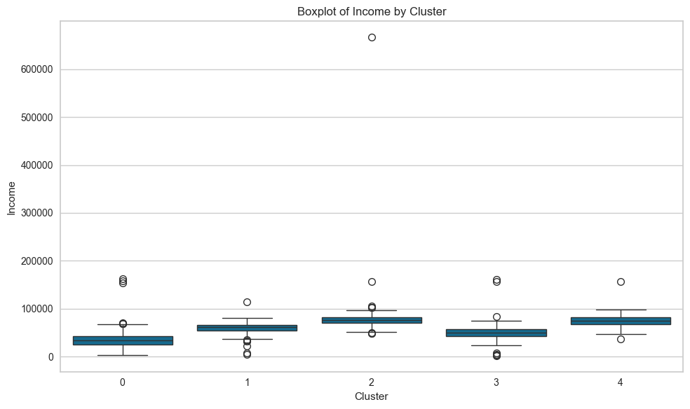

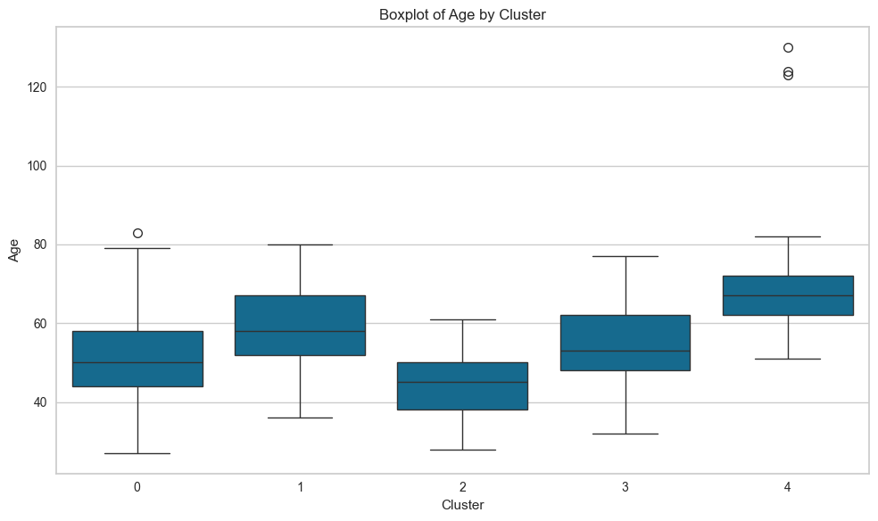

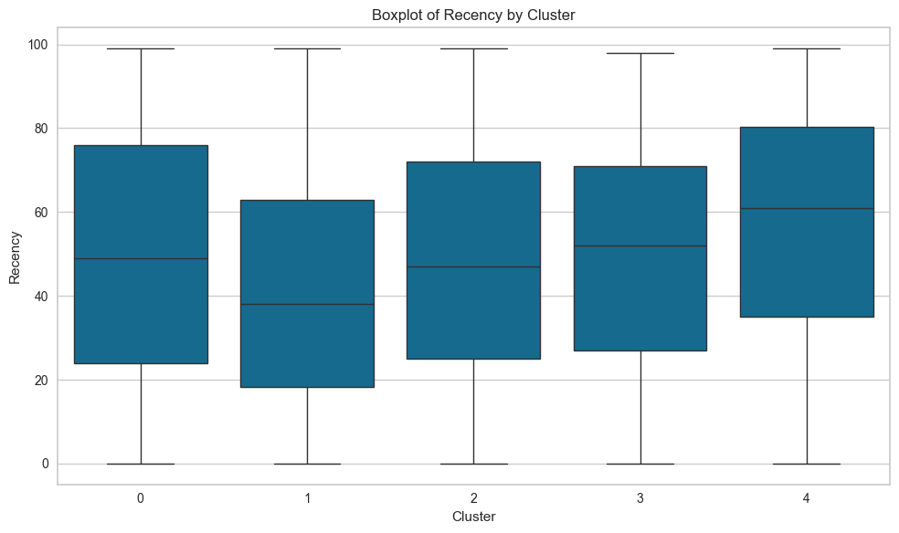

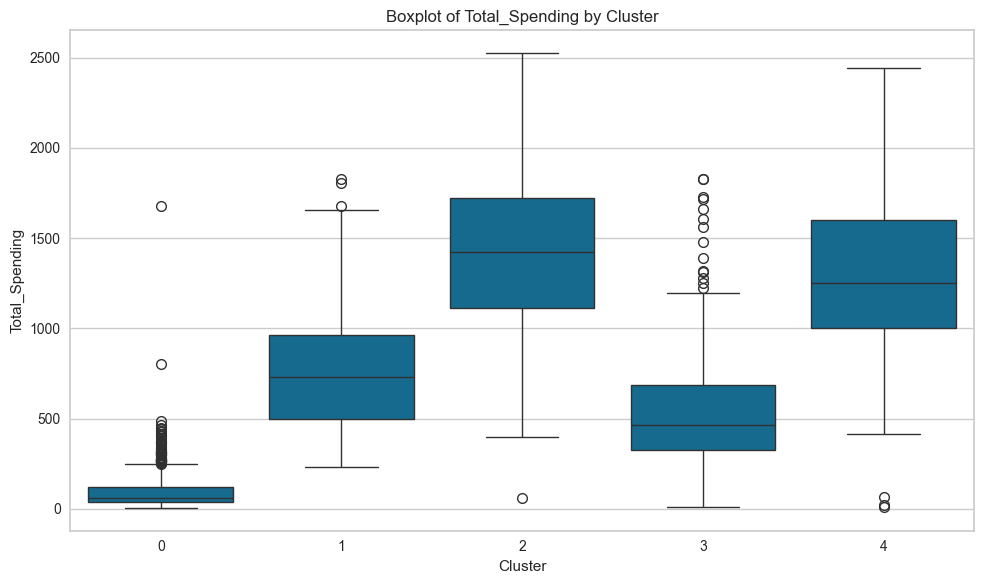

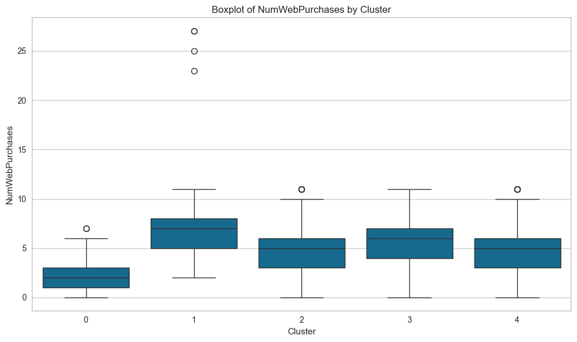

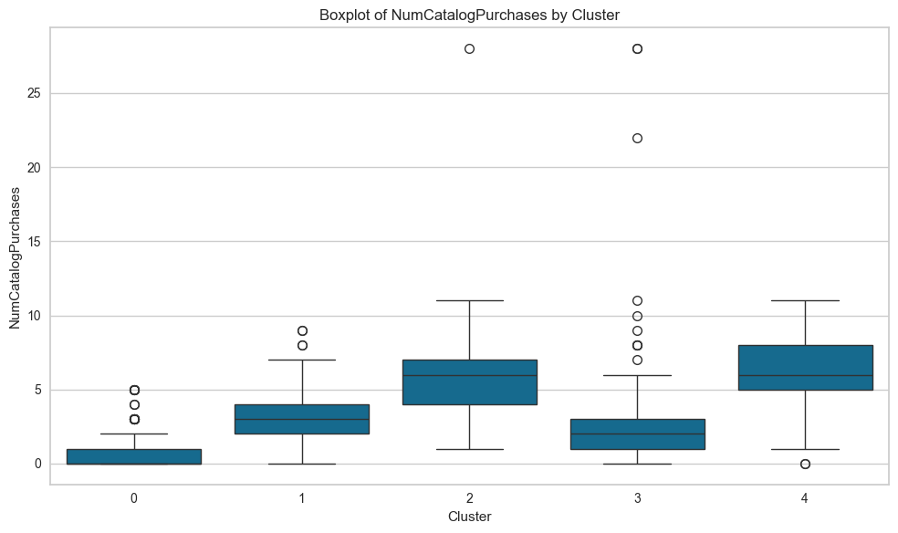

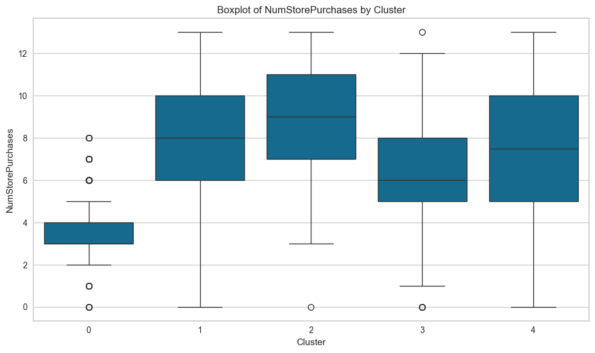

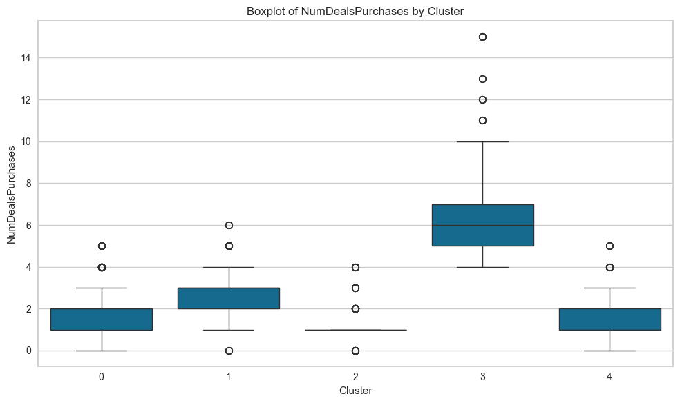

```python
# Perform cluster profiling using boxplots for the K-Means algorithm
# Create boxplots for each feature grouped by cluster
def plot_boxplots(data, features, cluster_col):
    """Plot boxplots for each feature grouped by cluster."""
    for feature in features:
        plt.figure(figsize=(10, 6))
        sns.boxplot(x=cluster_col, y=feature, data=data)
        plt.title(f'Boxplot of {feature} by Cluster')
        plt.xlabel('Cluster')
        plt.ylabel(feature)
        plt.tight_layout()
        plt.show()
# Call the function to plot boxplots for all features
plot_boxplots(data, features_for_clustering, 'Cluster')
```

##### **Observations:**

#### **Question 11**: Perform cluster profiling on the data using a barplot for the K-Means algorithm. Provide insights and key observations for each cluster based on the visual analysis.

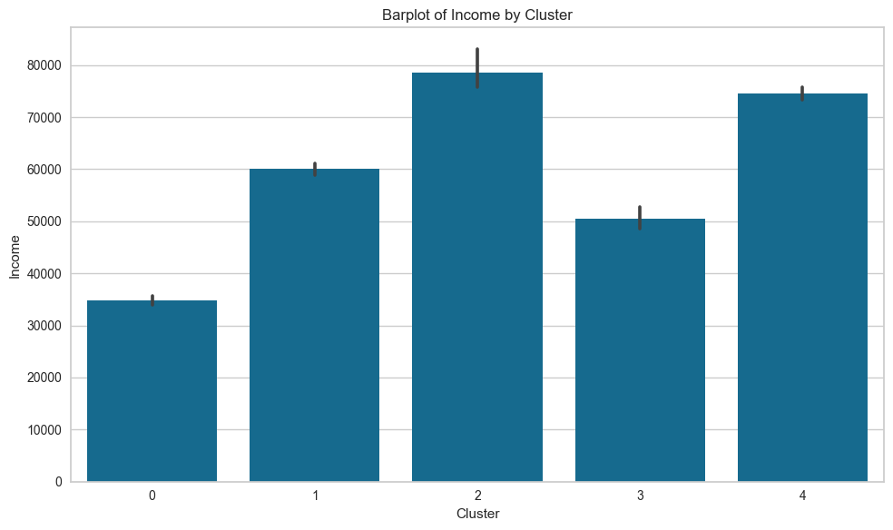

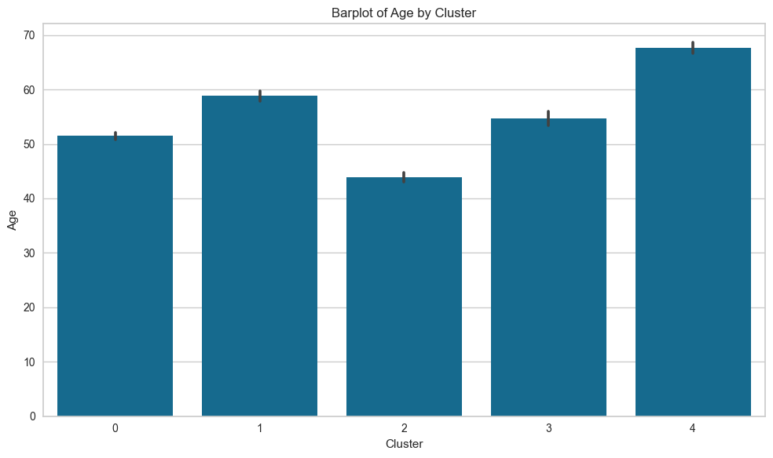

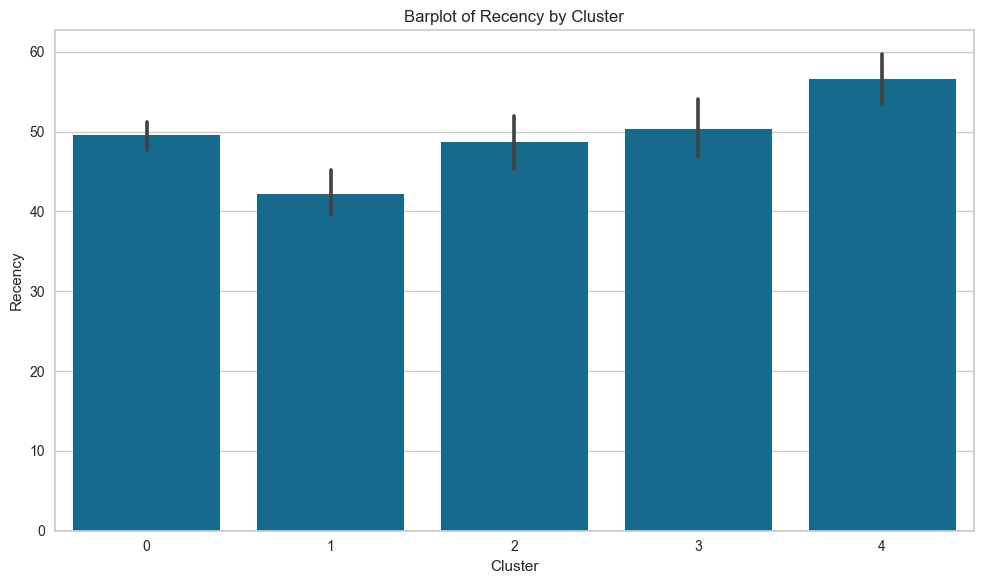

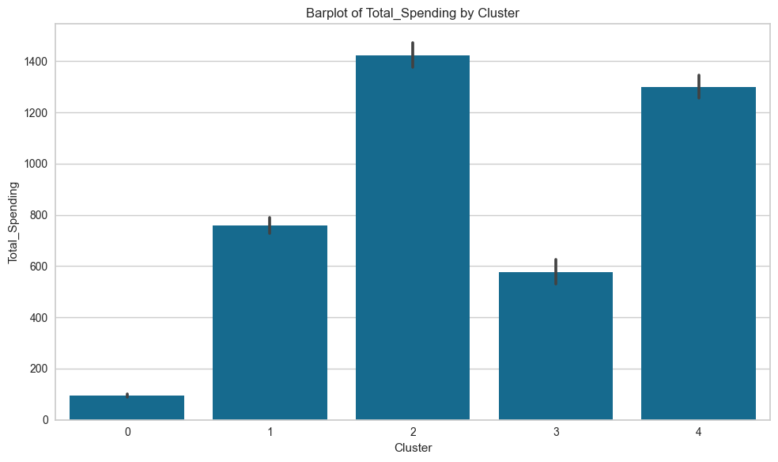

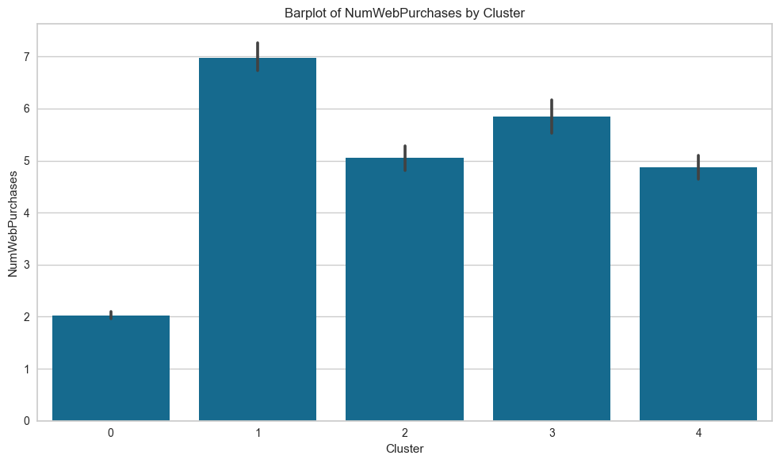

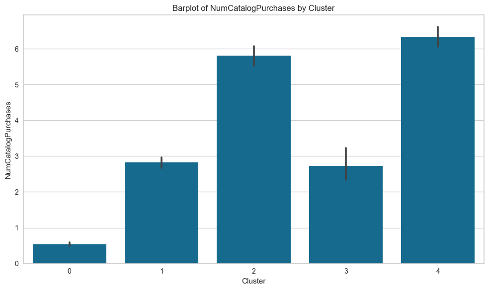

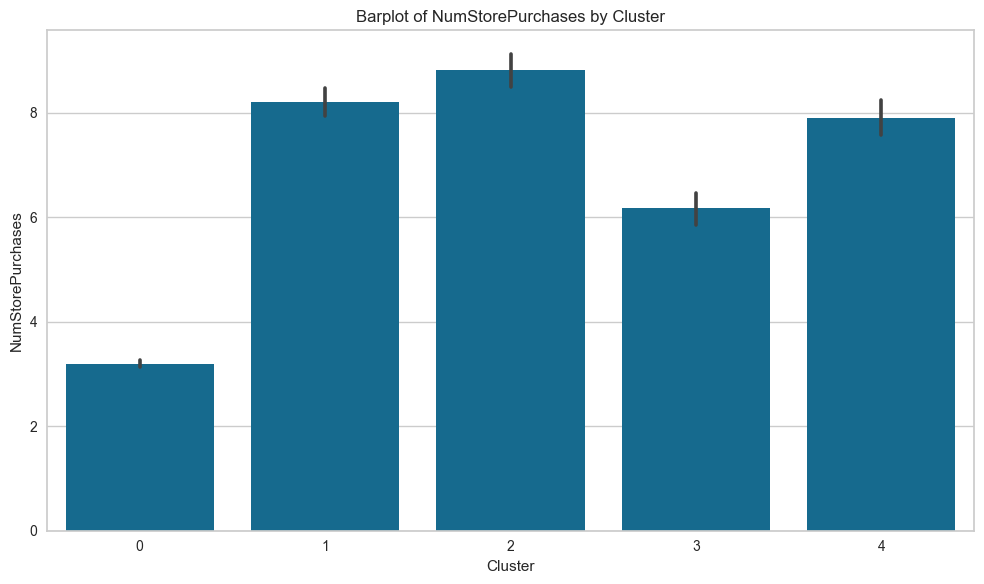

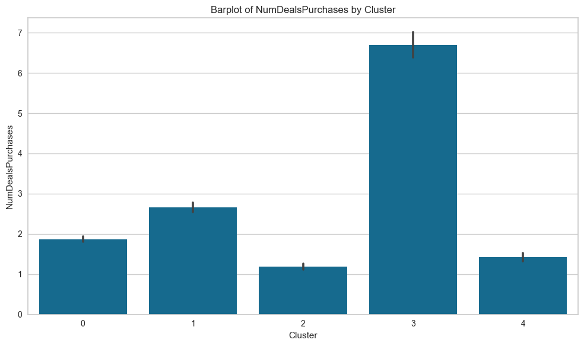

```python
#Perform cluster profiling on the data using a barplot for the K-Means algorithm
def plot_barplots(data, features, cluster_col):
    """Plot barplots for each feature grouped by cluster."""
    for feature in features:
        plt.figure(figsize=(10, 6))
        sns.barplot(x=cluster_col, y=feature, data=data, estimator=np.mean)
        plt.title(f'Barplot of {feature} by Cluster')
        plt.xlabel('Cluster')
        plt.ylabel(feature)
        plt.tight_layout()
        plt.show()
# Call the function to plot barplots for all features
plot_barplots(data, features_for_clustering, 'Cluster')
```

##### **Observations:**

## **Business Recommedations**

#### **Question 12**: Based on the cluster insights, what business recommendations can be provided?

Create premium loyalty programs specifically designed for high-spending customers Develop exclusive wine club memberships with special access to premium selections Implement personalized recommendations based on past purchases in higher-value categories Design elegant, sophisticated marketing materials that appeal to this demographic's taste profile

Create family bundle deals that provide value on essential products Develop special promotions during back-to-school seasons or holidays Introduce children-focused product lines with attractive packaging Implement loyalty programs that reward consistent family shopping Design convenient shopping experiences that accommodate families (both online and in-store)

Enhance the website user experience with advanced filtering and recommendation features targeted at higher education segments Optimize the in-store experience for customers who prefer physical shopping Develop hybrid shopping experiences (like click-and-collect) to bridge channel preferences Create channel-specific promotions based on customer segment preferences Tailor catalog designs based on the education level of the target audience

Analyze and replicate elements from the most successful campaigns (like Campaign 5) Develop segment-specific campaign approaches rather than one-size-fits-all marketing Implement A/B testing strategies to continuously optimize campaign performance Reduce marketing spend on unresponsive segments to improve marketing ROI Create an incremental engagement strategy for customers who have responded to previous campaigns

Develop a re-engagement campaign specifically targeting dormant high-value customers Offer special "we miss you" promotions with time-limited incentives Create personalized offers based on their previous purchase history Implement a win-back program with gradually increasing incentives Gather feedback from these customers to understand why they stopped purchasing

Ensure product assortment strategies align with age-based preferences Position premium wine selections for the 51-65 demographic Create targeted promotions for sweet products aimed at younger customers Develop age-appropriate loyalty programs with relevant rewards Tailor seasonal promotions to align with age-group shopping patterns

Optimize inventory levels based on segment-specific purchasing patterns Design store layouts to facilitate segment-specific shopping journeys Implement dynamic pricing strategies based on product affinity among different segments Train store staff to recognize and appropriately engage with different customer segments Schedule staffing based on when high-value segments typically shop

Develop new products aligned with the preferences of highest-value segments Test product concepts with specific customer segments before full launch Consider creating segment-specific product variations for existing high-performing products Evaluate underperforming product categories against segment preferences Gather segment-specific feedback for product enhancement